# Testing Additivity of Lead and Benzo[a]pyrene–induced Neurotoxicity in *Caenorhabditis elegans* Assays

Niccolò Anceschi

# 1 Overview

The convex-mixture model employed represents every ordinal damage-score distribution as $(1-\lambda)F_0 + \lambda F_\infty$, interpolating between an unexposed and a maximal-effect profile. The dose dependence enters entirely through the weight $\lambda(\cdot)$, a monotone non-decreasing function that governs the whole outcome distribution. Under joint exposure, it becomes a surface $\lambda_{12}(d_1,d_2)$ over the dose plane. Additivity is tested by a likelihood ratio comparing the fitted joint model against different nulls – Bliss, Loewe$^+$, and Hand – each inducing an additive baseline surface $\lambda_{12}^{(o)}$ built from the single-exposure fits.

# 2 Configuration

When this document is opened in RStudio, the repository path is detected automatically from the file’s location, so no manual editing is needed. `data_file` names the pre-processed data expected alongside the scripts.

```r
source_dir <- dirname(rstudioapi::getSourceEditorContext()$path) # repo local path
data_file <- "C-elgans_preprocessed_data.rds" # pre-processed data file
```

# 3 Utilities

Load required packages and define generic helpers (softmax, mixture probabilities, monotone inversion by root-finding).

```r
source(file.path(source_dir, "Utils.R"))
```

# 4 Data import and setup

Import the pre-processed assay data and build everything that does *not* depend on the fitted parameters: the single- and joint-exposure spline bases, the dose constants and spline dimensions, the extremal-profile PMFs, and nested exposure data subsets.

```r
source(file.path(source_dir, "Data_setup.R"))
```

# 5 Likelihoods and radial splines

Define the likelihood functions — both for single and joint exposures — and the penalized radial-spline objective — together with the caching helpers that keep each optimizer step cheap.

```r
source(file.path(source_dir, "Loglikelihood.R"))
```

# 6 Additive null models

Define the three additive baselines $\lambda_{12}^{(o)}(d_1,d_2)$ — Bliss, Loewe$^+$ (EME), and Hand — using spline parameters to be fitted on single-exposure data.

```r
source(file.path(source_dir, "Null_models.R"))
```

# 7 Model fit

Fit the two stages: first the single-exposure behavior for both BaP and Pb, then the joint-exposure surface via radial-splines under a monotonicity penalty. This is the computational core; the timing messages from `tic()`/`toc()` report each fit.

```r
source(file.path(source_dir, "Model_fit.R"))
```

```
## Fit Single-Exposure Data: 2.414 sec elapsed
## Fit Joint-Exposure Data: 12.724 sec elapsed
```

# 8 Result Visualization

Produce the fitted weight-function plots, the joint weight-surface contours for each null and for the radial fit, the fitted-vs-empirical CDF scatterplots, and the across-subset log-likelihood comparison.

```r
source(file.path(source_dir, "Plots.R"))
```

Single-exposure weight functions and the Pb→BaP dose alignment.

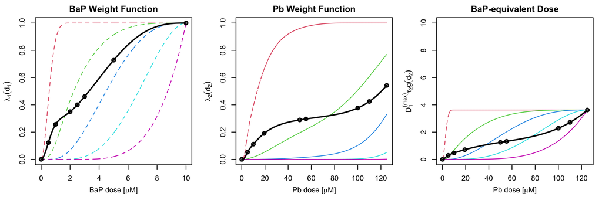

```r
plot_weight_functions(save = FALSE)
```

Joint weight surfaces: the three additive nulls and the radial fit.

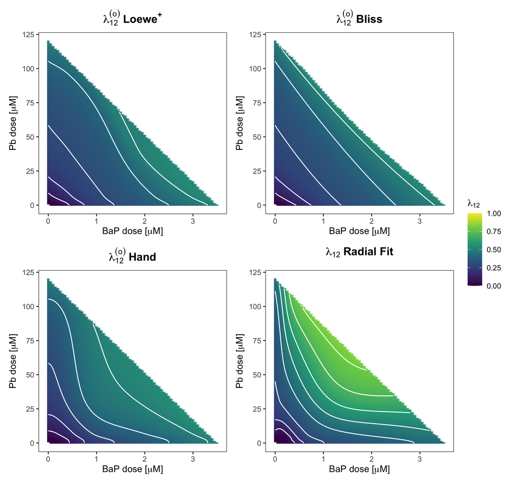

```r
plot_weight_surfaces(save = FALSE)
```

Log-likelihood across data subsets and models.

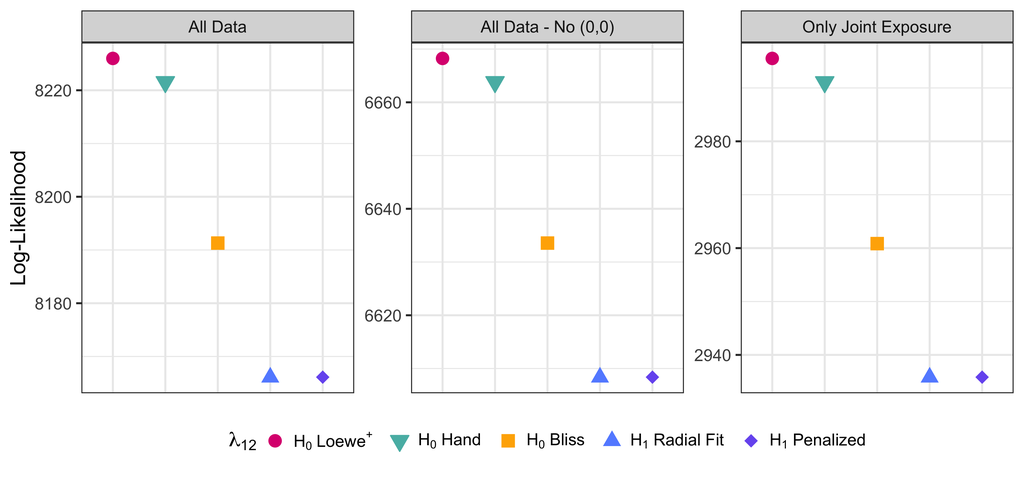

```r
plot_loglik(save = FALSE)
```

Fitted vs. empirical CDFs, all data and joint exposures only.

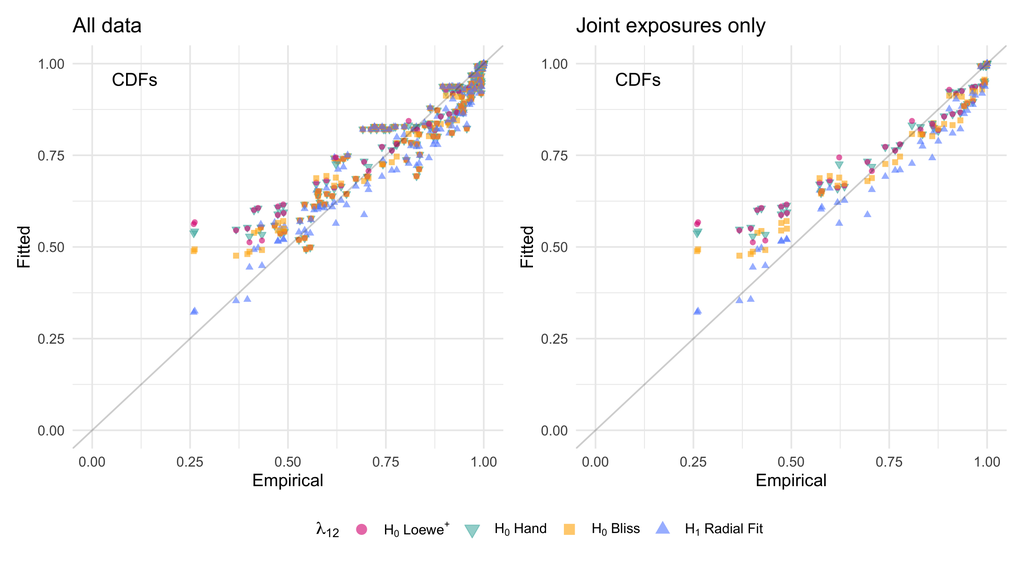

```r
plot_cdf_scatter(save = FALSE)
```

# 9 Bootstrap Test for Additivity

The additivity tests are calibrated by a parametric conditional bootstrap: for each null model, replicate datasets of the joint exposures data are drawn from the corresponding additive baseline, the radial surface is refitted on each, and the likelihood-ratio statistic is recomputed to build its null distribution – from which p-values and power are obtained.

Refitting the model on every replicate is computationally intensive: the analysis in the manuscript used 10,000 replicates per hypothesis and was run in parallel across multiple nodes on a computing cluster.

For transparency and completeness, the full procedure – replicate simulation, aggregation, and computation of the test statistics, p-values, and power – is provided in `Bootstrap_test.R`.